🏛️ Cabrillo National Monument

# Acknowledgements

The Cabrillo native bee monitoring program is the work of many hands. Since 2021, these are the people and partners who made it possible.

← Back to main page

## Research Team

The people who lead the native bee monitoring program.

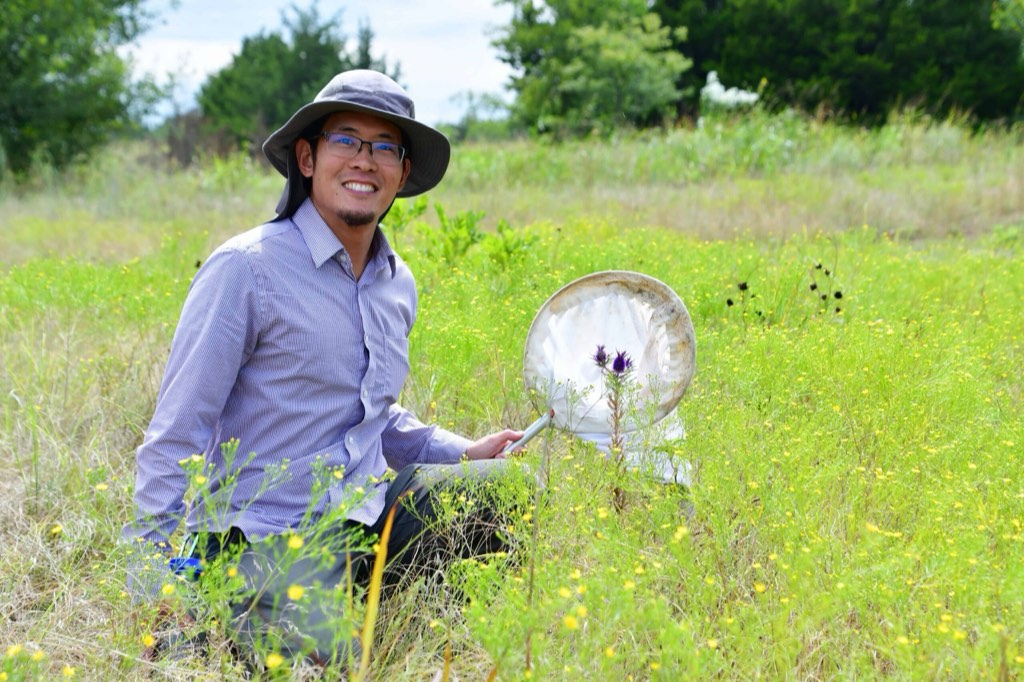

Keng-Lou James Hung[@kjhung](https://www.inaturalist.org/people/kjhung)Principal InvestigatorDepartment of Chemistry & Biology; Toronto Metropolitan University

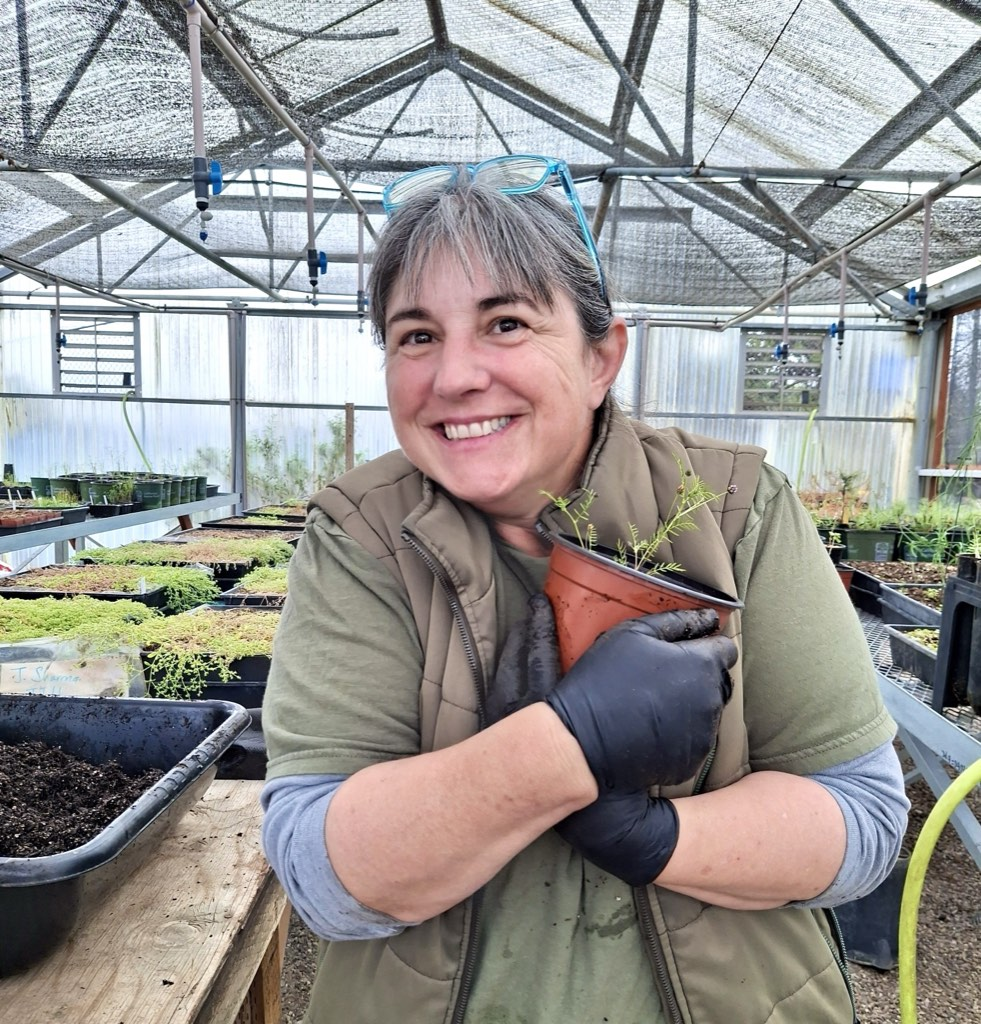

Patricia Simpson[@patsimpson2000](https://www.inaturalist.org/people/patsimpson2000)Science TechnicianCalifornia Wildlife Foundation, Cabrillo National Monument

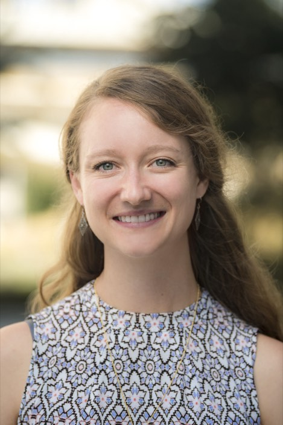

Jessica Mullins[@jessmullins](https://www.inaturalist.org/people/jessmullins)Entomologist ResearcherDepartment of Biology, Ecology, Behavior and Evolution; University of California, San Diego

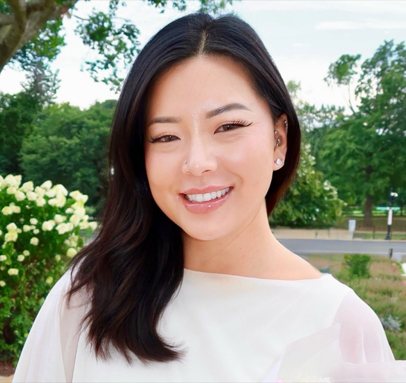

Ashley KimEntomologist Researcher and Intern CoordinatorDepartment of Biology, Ecology, Behavior and Evolution; University of California, San Diego

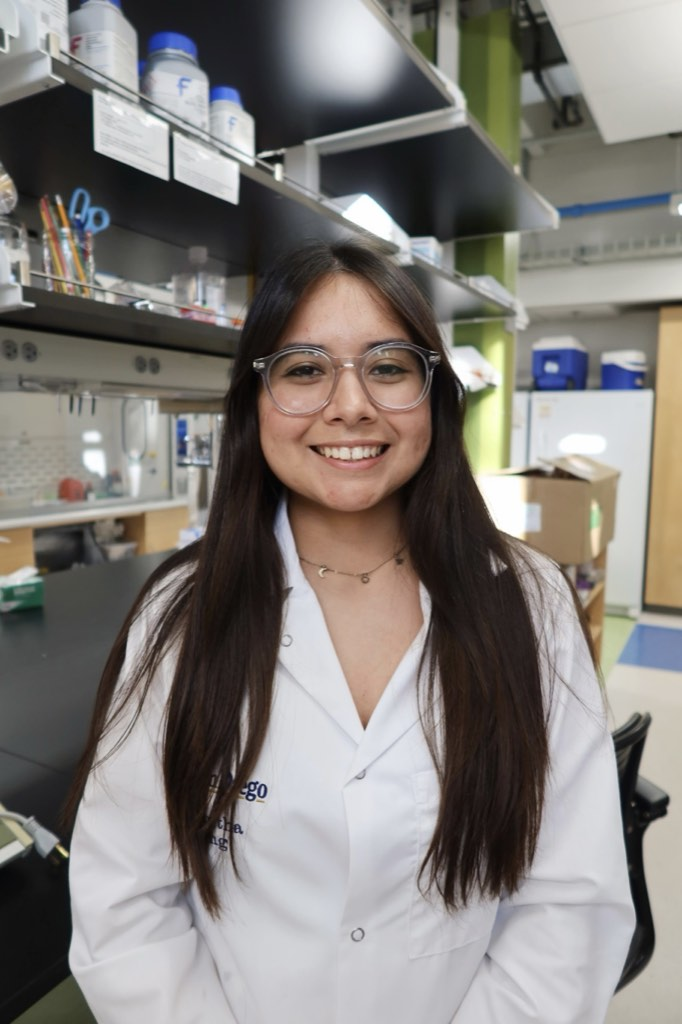

Brandi Sanchez[@randombirdlover](https://www.inaturalist.org/people/randombirdlover)Natural Resource Management Research AssistantConservation Legacy, Scientists in Parks, Cabrillo National Monument

[figure not shown]

Taro Katayama[@tarotarotaro](https://www.inaturalist.org/people/tarotarotaro)BiologistNational Park Service, Cabrillo National Monument

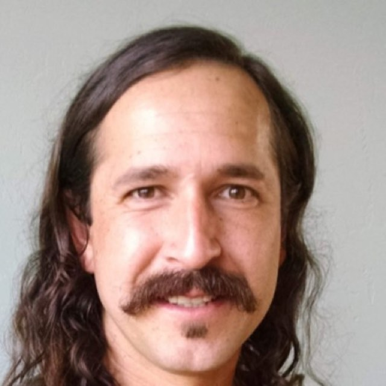

Sam O'Dell[@wranglebees](https://www.inaturalist.org/people/wranglebees)EntomologistDepartment of Biological Sciences; University of Oklahoma

## Partners

Institutions that host the program, the collections, and the data.

[Cabrillo National Monument](https://www.nps.gov/cabr/) [National Park Service](https://www.nps.gov/) [San Diego Natural History Museum](https://www.sdnhm.org/) [UC San Diego](https://www.ucsd.edu/) [iNaturalist](https://www.inaturalist.org/)

## Identification Team

The specialists who put names to the bees and plants!

Patricia Simpson[@patsimpson2000](https://www.inaturalist.org/people/patsimpson2000)California Wildlife Foundation, Cabrillo National Monument · bees & plants

Jessica Mullins[@jessmullins](https://www.inaturalist.org/people/jessmullins)Department of Biology, Ecology, Behavior and Evolution; University of California, San Diego · bees

John Ascher[@johnascher](https://www.inaturalist.org/people/johnascher)Department of Biological Sciences; National University of Singapore · bees

Brandi Sanchez[@randombirdlover](https://www.inaturalist.org/people/randombirdlover)Conservation Legacy, Scientists in Parks, Cabrillo National Monument · bees & plants

Keng-Lou James Hung[@kjhung](https://www.inaturalist.org/people/kjhung)Department of Chemistry & Biology; Toronto Metropolitan University · bees

Jack[@itazura](https://www.inaturalist.org/people/itazura)Grade school student · bees

Sam O'Dell[@wranglebees](https://www.inaturalist.org/people/wranglebees)Department of Biological Sciences; University of Oklahoma · bees & plants

Christopher Wilson[@cgwilson](https://www.inaturalist.org/people/cgwilson)Department of Biological Sciences; University of Arkansas · bees

Zachary Portman[@zportman](https://www.inaturalist.org/people/zportman)Department of Entomology; University of Minnesota · bees

Joel Gardner[@chloralictus](https://www.inaturalist.org/people/chloralictus)Department of Entomology; Washington State University · bees

Diego de PedroDepartment of Conservation Biology; Center for Scientific Research and Higher Education at Ensenada · bees

Isabel Hui[@izzyhui](https://www.inaturalist.org/people/izzyhui)Department of Biology, Ecology, Behavior and Evolution; University of California, San Diego · bees

Douglas Yanega[@dyanega](https://www.inaturalist.org/people/dyanega)Department of Entomology; University of California, Riverside · bees

Jon Rebman[@jrebman](https://www.inaturalist.org/people/jrebman)Department of Botany; San Diego Natural History Museum · plants

Sofia Campuzano Vallejo[@supremeweeder](https://www.inaturalist.org/people/supremeweeder)California Wildlife Foundation, Cabrillo National Monument · plants

Taro Katayama[@tarotarotaro](https://www.inaturalist.org/people/tarotarotaro)National Park Service, Cabrillo National Monument · plants

And to the rest of the iNaturalist community who have helped identify our bees, thank you.

## Survey Team

The people who walked the transects, photographed bees, and collected specimens. iNaturalist handles link to their profiles.

Cindy Pencek[@carrotpeople](https://www.inaturalist.org/people/carrotpeople)

Patricia Simpson[@patsimpson2000](https://www.inaturalist.org/people/patsimpson2000)

Bonnie Nickel[@bonnienickel](https://www.inaturalist.org/people/bonnienickel)

Craig Chaddock[@thumbwave](https://www.inaturalist.org/people/thumbwave)

Mark James[@markkjames](https://www.inaturalist.org/people/markkjames)

Tom Barnes[@tom_barnes_](https://www.inaturalist.org/people/tom_barnes_)

Phil Roullard[@proullard](https://www.inaturalist.org/people/proullard)

Ian Hicke[@therealian](https://www.inaturalist.org/people/therealian)

Misha Ingraham[@snugglymisha](https://www.inaturalist.org/people/snugglymisha)

Megan Hewitt[@rodeoclown](https://www.inaturalist.org/people/rodeoclown)

Xiomara Gaeta

Jilian Menez[@khoshakh](https://www.inaturalist.org/people/khoshakh)

Brandi Sanchez[@randombirdlover](https://www.inaturalist.org/people/randombirdlover)

Julia Showalter[@jwanderer6](https://www.inaturalist.org/people/jwanderer6)

Julia Keum[@julaliak](https://www.inaturalist.org/people/julaliak)

Sam O'Dell[@wranglebees](https://www.inaturalist.org/people/wranglebees)

Adrian Zenteno

Jasmine Hubbard[@jasminehubbard](https://www.inaturalist.org/people/jasminehubbard)

Grant Wass[@grant65](https://www.inaturalist.org/people/grant65)

Lydia Duran

Cassidy Samovar

Amy Geffre[@littlebeezer](https://www.inaturalist.org/people/littlebeezer)

Michael Ready[@mjready](https://www.inaturalist.org/people/mjready)

Francheska Tenderro

Min Han

Elena Oey[@u_phantasticus](https://www.inaturalist.org/people/u_phantasticus)

Hector Valtierra[@biohexx1](https://www.inaturalist.org/people/biohexx1)

Anahi Mendez Lozano

Darren Milama

Luis Cabrera[@luis1682](https://www.inaturalist.org/people/luis1682)

Nico Gamboa[@nicog4114](https://www.inaturalist.org/people/nicog4114)

Ava Wangen[@avawangen](https://www.inaturalist.org/people/avawangen)

Jorge Ayon[@chrysaetos](https://www.inaturalist.org/people/chrysaetos)

Winsten Slowswakey[@slowswakey](https://www.inaturalist.org/people/slowswakey)

And to the rest of the iNaturalist community who have shared observations from the park, thank you.